# Tasca M6 T01

## Exercici 1

#### Crea almenys dos models de regressió diferents per intentar predir el millor possible el preu de les vivendes (MEDV) de l'arxiu adjunt.

```python
# Tratamiento de datos
# ==============================================================================
import pandas as pd
import numpy as np

# Gráficos
# ==============================================================================
import matplotlib.pyplot as plt
from matplotlib import style
import matplotlib.ticker as ticker
import seaborn as sns
from pprint import pprint

# Preprocesado y análisis
# ==============================================================================
#import statsmodels.api as sm
#import pingouin as pg
from scipy import stats
import random as rd
from imblearn.over_sampling import SMOTE

# Preprocesado y modelado
# ==============================================================================
from sklearn.datasets import load_boston
from sklearn.ensemble import RandomForestRegressor
from sklearn.metrics import mean_absolute_error
from sklearn.metrics import mean_squared_error
from sklearn.metrics import accuracy_score
from sklearn import metrics
from sklearn.model_selection import cross_val_score
from sklearn.model_selection import train_test_split
from sklearn.model_selection import RepeatedKFold
from sklearn.model_selection import GridSearchCV
from sklearn.model_selection import ParameterGrid
from sklearn.tree import DecisionTreeRegressor
from sklearn.tree import plot_tree
from sklearn.tree import export_text
from sklearn.inspection import permutation_importance
import multiprocessing
from sklearn import neighbors, datasets, preprocessing
from sklearn.preprocessing import Normalizer
from sklearn.preprocessing import MinMaxScaler
from sklearn.preprocessing import StandardScaler
from sklearn.preprocessing import PolynomialFeatures
from sklearn import datasets
from sklearn.model_selection import KFold
import statsmodels.api as sm
from sklearn.model_selection import cross_val_predict


# Test Estadísticos
# ==============================================================================
from scipy.stats import pearsonr
from statistics import mode
from scipy.stats import shapiro
from scipy.stats import normaltest
from scipy.stats import anderson
from scipy.stats import pearsonr
from scipy.stats import spearmanr
from scipy.stats import kendalltau
from scipy.stats import chi2_contingency
from statsmodels.tsa.stattools import adfuller
from statsmodels.tsa.stattools import kpss
from scipy.stats import ttest_ind
from scipy.stats import ttest_rel
from scipy.stats import f_oneway
from scipy.stats import mannwhitneyu
from scipy.stats import wilcoxon
from scipy.stats import kruskal
from scipy.stats import friedmanchisquare

# Ajuste de distribuciones
# ==============================================================================
from scipy import stats
import inspect
from statsmodels.distributions.empirical_distribution import ECDF


# Configuración matplotlib
# ==============================================================================
plt.style.use('ggplot')
from statsmodels.graphics.gofplots import qqplot
from matplotlib import pyplot

# Configuración warnings
# ==============================================================================
import warnings
warnings.filterwarnings('ignore')
```

#### A) Data Frame

```python
data= pd.read_csv(r"C:\Users\hecto\OneDrive\Documentos\IT Data Science\Sprint5_DS\datos\housing data.csv",header=None)
data_original =data
data_original.head(5)
```

|  | 0 | 1 | 2 | 3 | 4 | 5 | 6 | 7 | 8 | 9 | 10 | 11 | 12 | 13 |
| --- | --- | --- | --- | --- | --- | --- | --- | --- | --- | --- | --- | --- | --- | --- |
| 0 | 0.00632 | 18.0 | 2.31 | 0 | 0.538 | 6.575 | 65.2 | 4.0900 | 1 | 296.0 | 15.3 | 396.90 | 4.98 | 24.0 |
| 1 | 0.02731 | 0.0 | 7.07 | 0 | 0.469 | 6.421 | 78.9 | 4.9671 | 2 | 242.0 | 17.8 | 396.90 | 9.14 | 21.6 |
| 2 | 0.02729 | 0.0 | 7.07 | 0 | 0.469 | 7.185 | 61.1 | 4.9671 | 2 | 242.0 | 17.8 | 392.83 | 4.03 | 34.7 |
| 3 | 0.03237 | 0.0 | 2.18 | 0 | 0.458 | 6.998 | 45.8 | 6.0622 | 3 | 222.0 | 18.7 | 394.63 | 2.94 | 33.4 |
| 4 | 0.06905 | 0.0 | 2.18 | 0 | 0.458 | 7.147 | 54.2 | 6.0622 | 3 | 222.0 | 18.7 | 396.90 | 5.33 | 36.2 |

Relevant Information: Concerns housing values in suburbs of Boston.

- Number of Instances: 506
- Number of Attributes: 13 continuous attributes (including "class" attribute "MEDV"), 1 binary-valued attribute.
- Attribute Information:
  1. CRIM : per capita crime rate by town
  2. ZN : proportion of residential land zoned for lots over "25,000 sq.ft".
  3. INDUS : proportion of non-retail business acres per town
  4. CHAS : Charles River dummy variable (= 1 if tract bounds river; 0 otherwise)
  5. NOX : nitric oxides concentration (parts per 10 million)
  6. RM : average number of rooms per dwelling
  7. AGE : proportion of owner-occupied units built prior to 1940
  8. DIS: weighted distances to five Boston employment centres
  9. RAD . index of accessibility to radial highways
  10. TAX : full-value property-tax rate per 10.000 dólares
  11. PTRATIO: pupil-teacher ratio by town
  12. B : "1000(Bk - 0.63)^2" where Bk is the proportion of blacks by town
  13. LSTAT : % lower status of the population
  14. MEDV : Median value of owner-occupied homes in "$1000's"

```python
data.columns =["CRIM","ZN","INDUS","CHAS","NOX","RM","AGE","DIS","RAD","TAX","PTRATIO","B","LSTAT","MEDV"]
data.head()
```

|  | CRIM | ZN | INDUS | CHAS | NOX | RM | AGE | DIS | RAD | TAX | PTRATIO | B | LSTAT | MEDV |
| --- | --- | --- | --- | --- | --- | --- | --- | --- | --- | --- | --- | --- | --- | --- |
| 0 | 0.00632 | 18.0 | 2.31 | 0 | 0.538 | 6.575 | 65.2 | 4.0900 | 1 | 296.0 | 15.3 | 396.90 | 4.98 | 24.0 |
| 1 | 0.02731 | 0.0 | 7.07 | 0 | 0.469 | 6.421 | 78.9 | 4.9671 | 2 | 242.0 | 17.8 | 396.90 | 9.14 | 21.6 |
| 2 | 0.02729 | 0.0 | 7.07 | 0 | 0.469 | 7.185 | 61.1 | 4.9671 | 2 | 242.0 | 17.8 | 392.83 | 4.03 | 34.7 |
| 3 | 0.03237 | 0.0 | 2.18 | 0 | 0.458 | 6.998 | 45.8 | 6.0622 | 3 | 222.0 | 18.7 | 394.63 | 2.94 | 33.4 |
| 4 | 0.06905 | 0.0 | 2.18 | 0 | 0.458 | 7.147 | 54.2 | 6.0622 | 3 | 222.0 | 18.7 | 396.90 | 5.33 | 36.2 |

```python
data.describe().transpose()
```

|  | count | mean | std | min | 25% | 50% | 75% | max |
| --- | --- | --- | --- | --- | --- | --- | --- | --- |
| CRIM | 506.0 | 3.613524 | 8.601545 | 0.00632 | 0.082045 | 0.25651 | 3.677083 | 88.9762 |
| ZN | 506.0 | 11.363636 | 23.322453 | 0.00000 | 0.000000 | 0.00000 | 12.500000 | 100.0000 |
| INDUS | 506.0 | 11.136779 | 6.860353 | 0.46000 | 5.190000 | 9.69000 | 18.100000 | 27.7400 |
| CHAS | 506.0 | 0.069170 | 0.253994 | 0.00000 | 0.000000 | 0.00000 | 0.000000 | 1.0000 |
| NOX | 506.0 | 0.554695 | 0.115878 | 0.38500 | 0.449000 | 0.53800 | 0.624000 | 0.8710 |
| RM | 506.0 | 6.284634 | 0.702617 | 3.56100 | 5.885500 | 6.20850 | 6.623500 | 8.7800 |
| AGE | 506.0 | 68.574901 | 28.148861 | 2.90000 | 45.025000 | 77.50000 | 94.075000 | 100.0000 |
| DIS | 506.0 | 3.795043 | 2.105710 | 1.12960 | 2.100175 | 3.20745 | 5.188425 | 12.1265 |
| RAD | 506.0 | 9.549407 | 8.707259 | 1.00000 | 4.000000 | 5.00000 | 24.000000 | 24.0000 |
| TAX | 506.0 | 408.237154 | 168.537116 | 187.00000 | 279.000000 | 330.00000 | 666.000000 | 711.0000 |
| PTRATIO | 506.0 | 18.455534 | 2.164946 | 12.60000 | 17.400000 | 19.05000 | 20.200000 | 22.0000 |
| B | 506.0 | 356.674032 | 91.294864 | 0.32000 | 375.377500 | 391.44000 | 396.225000 | 396.9000 |
| LSTAT | 506.0 | 12.653063 | 7.141062 | 1.73000 | 6.950000 | 11.36000 | 16.955000 | 37.9700 |
| MEDV | 506.0 | 22.532806 | 9.197104 | 5.00000 | 17.025000 | 21.20000 | 25.000000 | 50.0000 |

- Para tener una mejor aproximación a la dispersión de cada una de las variables explicativas hemos realizado la gráfica boxplot de cada una de ellas separadas en dos grupos diferenciados las que su rango de valores es inferior a 100, y las que superan este rango, que son la variable TAX y B.

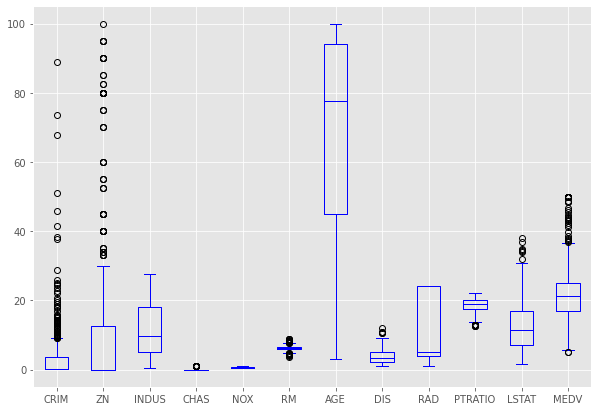

```python
data_sin= data.drop(columns=["TAX","B"])
data_sin.boxplot( grid = True, figsize=(10, 7), color="blue")
```

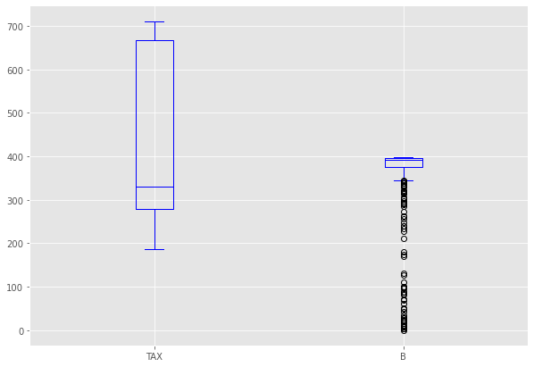

```python
data_tax_B= data[["TAX","B"]]
data_tax_B.boxplot(grid = True, figsize=(10, 7), color="blue")
```

- La variable TAX no presenta outliers a pesar de ser la que tiene el rango más amplio, mientras que la variable B que es el porcentaje de población negra, al estar ajustada a una función exponencial presenta outliers en los valores inferiores.

#### B) Media y Desviación Estándar de cada una de las variables

```python
df= data.describe().transpose()
data_medias=df[["mean","std"]]
data_medias
```

|  | mean | std |
| --- | --- | --- |
| CRIM | 3.613524 | 8.601545 |
| ZN | 11.363636 | 23.322453 |
| INDUS | 11.136779 | 6.860353 |
| CHAS | 0.069170 | 0.253994 |
| NOX | 0.554695 | 0.115878 |
| RM | 6.284634 | 0.702617 |
| AGE | 68.574901 | 28.148861 |
| DIS | 3.795043 | 2.105710 |
| RAD | 9.549407 | 8.707259 |
| TAX | 408.237154 | 168.537116 |
| PTRATIO | 18.455534 | 2.164946 |
| B | 356.674032 | 91.294864 |
| LSTAT | 12.653063 | 7.141062 |
| MEDV | 22.532806 | 9.197104 |

#### C) Creación de Columnas Dummies

Dado que la variable CHAS solo tiene dos valores, 1,0, no tiene sentido separar en Dummies esa información, ya que la propia columna la contiene. Sin embargo, si vamo a crear columnas Dummies de RAD, para ver si esta separación de la información, añade más precisión al modelo.

```python
# creamos dummy RAD
df=data
df=pd.get_dummies(df, columns=["RAD"],drop_first = False)
df.head()
```

|  | CRIM | ZN | INDUS | CHAS | NOX | RM | AGE | DIS | TAX | PTRATIO | ... | MEDV | RAD_1 | RAD_2 | RAD_3 | RAD_4 | RAD_5 | RAD_6 | RAD_7 | RAD_8 | RAD_24 |
| --- | --- | --- | --- | --- | --- | --- | --- | --- | --- | --- | --- | --- | --- | --- | --- | --- | --- | --- | --- | --- | --- |
| 0 | 0.00632 | 18.0 | 2.31 | 0 | 0.538 | 6.575 | 65.2 | 4.0900 | 296.0 | 15.3 | ... | 24.0 | 1 | 0 | 0 | 0 | 0 | 0 | 0 | 0 | 0 |
| 1 | 0.02731 | 0.0 | 7.07 | 0 | 0.469 | 6.421 | 78.9 | 4.9671 | 242.0 | 17.8 | ... | 21.6 | 0 | 1 | 0 | 0 | 0 | 0 | 0 | 0 | 0 |
| 2 | 0.02729 | 0.0 | 7.07 | 0 | 0.469 | 7.185 | 61.1 | 4.9671 | 242.0 | 17.8 | ... | 34.7 | 0 | 1 | 0 | 0 | 0 | 0 | 0 | 0 | 0 |
| 3 | 0.03237 | 0.0 | 2.18 | 0 | 0.458 | 6.998 | 45.8 | 6.0622 | 222.0 | 18.7 | ... | 33.4 | 0 | 0 | 1 | 0 | 0 | 0 | 0 | 0 | 0 |
| 4 | 0.06905 | 0.0 | 2.18 | 0 | 0.458 | 7.147 | 54.2 | 6.0622 | 222.0 | 18.7 | ... | 36.2 | 0 | 0 | 1 | 0 | 0 | 0 | 0 | 0 | 0 |

5 rows × 22 columns

#### D) Correlación entre las variables del Data Frame

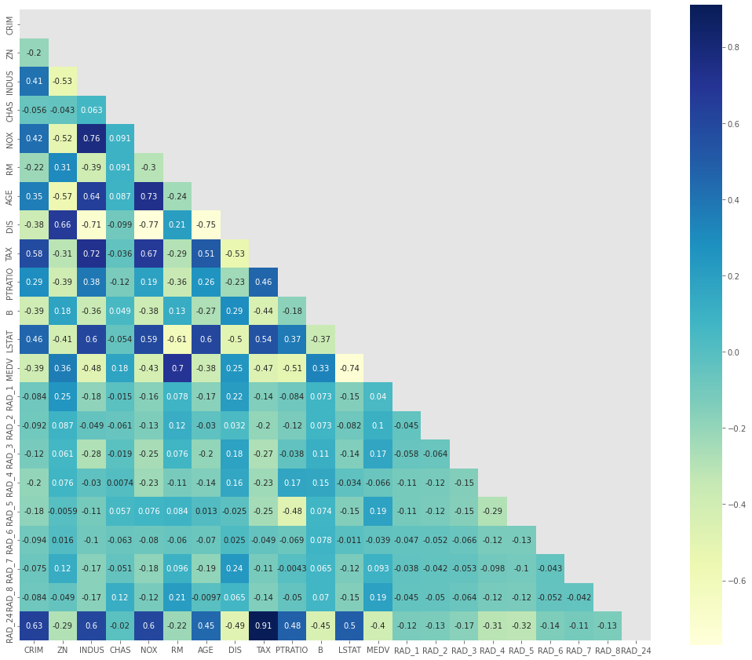

```python
plt.figure(figsize=(18,15))
upp_mat = np.triu(df.corr())
sns.heatmap(df.corr(),cmap="YlGnBu", square = True,annot=True, mask = upp_mat)
```

- Entre la variable objetivo MEDV y el resto de variables, la correlación (inversa) más elevada se da con la variable LSTAT que es el porcentaje de población con menos ingresos.En los Los barrios con más trabajadores de clase baja (mayor valor de ‘LSTAT’) los inmuebles valdrán men
- La siguiente variable con mayor correlación es RM que es el promedio de habitaciones por vivienda. Las casas con más habitaciones (valor más alto de ‘RM’) valdrán más. Por lo general, las casas con más habitaciones son más grandes y pueden acomodar a más personas, por lo que es razonable que cuesten más dinero. Son variables directamente proporcionales.
- Los vecindarios con más proporción de estudiantes por maestro (mayor valor de ‘PTRATIO’) el valor de las casas está inversamente correlacionado, Si el porcentaje de estudiantes por maestro es mayor, es probable que en el vecindario haya menos escuelas, o mayor densidad de población, por lo que influye negativamente en el valor de los inmuebles.
- Una vez aplicados los dummies sobre la variable RAD, los rangos de correlación de cada una de las variables RAD_* generadas vs MEDV, oscilan entre [-0,4 y 0.19] mientras que la correlación inical era de -0.38.

#### E) División de los datos en train y test

```python
# División de los datos en train y test
# ==============================================================================
#X_train, X_test, y_train, y_test = train_test_split(X, y, test_size=0.33, random_state=1)
X_train, X_test, y_train, y_test = train_test_split(df.drop(columns = "MEDV"),df['MEDV'], test_size=0.33, random_state = 1)
print(X_train.shape, X_test.shape, y_train.shape, y_test.shape)
```

```
(339, 21) (167, 21) (339,) (167,)
```

```python
X_train.head()
```

|  | CRIM | ZN | INDUS | CHAS | NOX | RM | AGE | DIS | TAX | PTRATIO | ... | LSTAT | RAD_1 | RAD_2 | RAD_3 | RAD_4 | RAD_5 | RAD_6 | RAD_7 | RAD_8 | RAD_24 |
| --- | --- | --- | --- | --- | --- | --- | --- | --- | --- | --- | --- | --- | --- | --- | --- | --- | --- | --- | --- | --- | --- |
| 378 | 23.64820 | 0.0 | 18.10 | 0 | 0.671 | 6.380 | 96.2 | 1.3861 | 666.0 | 20.2 | ... | 23.69 | 0 | 0 | 0 | 0 | 0 | 0 | 0 | 0 | 1 |
| 127 | 0.25915 | 0.0 | 21.89 | 0 | 0.624 | 5.693 | 96.0 | 1.7883 | 437.0 | 21.2 | ... | 17.19 | 0 | 0 | 0 | 1 | 0 | 0 | 0 | 0 | 0 |
| 82 | 0.03659 | 25.0 | 4.86 | 0 | 0.426 | 6.302 | 32.2 | 5.4007 | 281.0 | 19.0 | ... | 6.72 | 0 | 0 | 0 | 1 | 0 | 0 | 0 | 0 | 0 |
| 463 | 5.82115 | 0.0 | 18.10 | 0 | 0.713 | 6.513 | 89.9 | 2.8016 | 666.0 | 20.2 | ... | 10.29 | 0 | 0 | 0 | 0 | 0 | 0 | 0 | 0 | 1 |
| 207 | 0.25199 | 0.0 | 10.59 | 0 | 0.489 | 5.783 | 72.7 | 4.3549 | 277.0 | 18.6 | ... | 18.06 | 0 | 0 | 0 | 1 | 0 | 0 | 0 | 0 | 0 |

5 rows × 21 columns

```python
X_test.head()
```

|  | CRIM | ZN | INDUS | CHAS | NOX | RM | AGE | DIS | TAX | PTRATIO | ... | LSTAT | RAD_1 | RAD_2 | RAD_3 | RAD_4 | RAD_5 | RAD_6 | RAD_7 | RAD_8 | RAD_24 |
| --- | --- | --- | --- | --- | --- | --- | --- | --- | --- | --- | --- | --- | --- | --- | --- | --- | --- | --- | --- | --- | --- |
| 307 | 0.04932 | 33.0 | 2.18 | 0 | 0.472 | 6.849 | 70.3 | 3.1827 | 222.0 | 18.4 | ... | 7.53 | 0 | 0 | 0 | 0 | 0 | 0 | 1 | 0 | 0 |
| 343 | 0.02543 | 55.0 | 3.78 | 0 | 0.484 | 6.696 | 56.4 | 5.7321 | 370.0 | 17.6 | ... | 7.18 | 0 | 0 | 0 | 0 | 1 | 0 | 0 | 0 | 0 |
| 47 | 0.22927 | 0.0 | 6.91 | 0 | 0.448 | 6.030 | 85.5 | 5.6894 | 233.0 | 17.9 | ... | 18.80 | 0 | 0 | 1 | 0 | 0 | 0 | 0 | 0 | 0 |
| 67 | 0.05789 | 12.5 | 6.07 | 0 | 0.409 | 5.878 | 21.4 | 6.4980 | 345.0 | 18.9 | ... | 8.10 | 0 | 0 | 0 | 1 | 0 | 0 | 0 | 0 | 0 |
| 362 | 3.67822 | 0.0 | 18.10 | 0 | 0.770 | 5.362 | 96.2 | 2.1036 | 666.0 | 20.2 | ... | 10.19 | 0 | 0 | 0 | 0 | 0 | 0 | 0 | 0 | 1 |

5 rows × 21 columns

#### E.1) Descripción estadística de X_train -X-test

```python
X_train.describe().transpose()
```

|  | count | mean | std | min | 25% | 50% | 75% | max |
| --- | --- | --- | --- | --- | --- | --- | --- | --- |
| CRIM | 339.0 | 3.793986 | 8.669966 | 0.00632 | 0.08577 | 0.25387 | 3.81234 | 73.5341 |
| ZN | 339.0 | 10.963127 | 23.058729 | 0.00000 | 0.00000 | 0.00000 | 12.50000 | 100.0000 |
| INDUS | 339.0 | 11.377493 | 6.874160 | 0.46000 | 5.64000 | 9.90000 | 18.10000 | 27.7400 |
| CHAS | 339.0 | 0.079646 | 0.271145 | 0.00000 | 0.00000 | 0.00000 | 0.00000 | 1.0000 |
| NOX | 339.0 | 0.556238 | 0.117996 | 0.39200 | 0.44800 | 0.53800 | 0.62750 | 0.8710 |
| RM | 339.0 | 6.247490 | 0.669953 | 3.86300 | 5.87300 | 6.16700 | 6.58250 | 8.3980 |
| AGE | 339.0 | 69.173451 | 28.246657 | 6.00000 | 45.75000 | 79.70000 | 94.30000 | 100.0000 |
| DIS | 339.0 | 3.799550 | 2.114897 | 1.12960 | 2.09445 | 3.26280 | 5.03375 | 12.1265 |
| TAX | 339.0 | 408.890855 | 169.654094 | 187.00000 | 279.00000 | 330.00000 | 666.00000 | 711.0000 |
| PTRATIO | 339.0 | 18.418584 | 2.176714 | 12.60000 | 17.00000 | 19.00000 | 20.20000 | 22.0000 |
| B | 339.0 | 356.552537 | 92.095470 | 0.32000 | 375.99000 | 391.45000 | 396.06000 | 396.9000 |
| LSTAT | 339.0 | 13.087522 | 7.340139 | 1.73000 | 7.41500 | 12.03000 | 17.13500 | 37.9700 |
| RAD_1 | 339.0 | 0.038348 | 0.192319 | 0.00000 | 0.00000 | 0.00000 | 0.00000 | 1.0000 |
| RAD_2 | 339.0 | 0.056047 | 0.230353 | 0.00000 | 0.00000 | 0.00000 | 0.00000 | 1.0000 |
| RAD_3 | 339.0 | 0.070796 | 0.256864 | 0.00000 | 0.00000 | 0.00000 | 0.00000 | 1.0000 |
| RAD_4 | 339.0 | 0.209440 | 0.407510 | 0.00000 | 0.00000 | 0.00000 | 0.00000 | 1.0000 |
| RAD_5 | 339.0 | 0.230088 | 0.421511 | 0.00000 | 0.00000 | 0.00000 | 0.00000 | 1.0000 |
| RAD_6 | 339.0 | 0.053097 | 0.224559 | 0.00000 | 0.00000 | 0.00000 | 0.00000 | 1.0000 |
| RAD_7 | 339.0 | 0.032448 | 0.177450 | 0.00000 | 0.00000 | 0.00000 | 0.00000 | 1.0000 |
| RAD_8 | 339.0 | 0.044248 | 0.205949 | 0.00000 | 0.00000 | 0.00000 | 0.00000 | 1.0000 |
| RAD_24 | 339.0 | 0.265487 | 0.442245 | 0.00000 | 0.00000 | 0.00000 | 1.00000 | 1.0000 |

```python
X_test.describe().transpose()
```

|  | count | mean | std | min | 25% | 50% | 75% | max |
| --- | --- | --- | --- | --- | --- | --- | --- | --- |
| CRIM | 167.0 | 3.247195 | 8.474939 | 0.01096 | 0.076945 | 0.26169 | 3.122525 | 88.9762 |
| ZN | 167.0 | 12.176647 | 23.898258 | 0.00000 | 0.000000 | 0.00000 | 20.000000 | 95.0000 |
| INDUS | 167.0 | 10.648144 | 6.826662 | 1.25000 | 4.675000 | 8.56000 | 18.100000 | 27.7400 |
| CHAS | 167.0 | 0.047904 | 0.214206 | 0.00000 | 0.000000 | 0.00000 | 0.000000 | 1.0000 |
| NOX | 167.0 | 0.551563 | 0.111736 | 0.38500 | 0.458000 | 0.53200 | 0.624000 | 0.8710 |
| RM | 167.0 | 6.360036 | 0.761180 | 3.56100 | 5.979500 | 6.31000 | 6.630500 | 8.7800 |
| AGE | 167.0 | 67.359880 | 27.994376 | 2.90000 | 41.700000 | 73.30000 | 93.150000 | 100.0000 |
| DIS | 167.0 | 3.785894 | 2.093240 | 1.17810 | 2.101800 | 3.09230 | 5.307650 | 10.7103 |
| TAX | 167.0 | 406.910180 | 166.745525 | 188.00000 | 281.000000 | 337.00000 | 666.000000 | 711.0000 |
| PTRATIO | 167.0 | 18.530539 | 2.145399 | 13.00000 | 17.400000 | 19.10000 | 20.200000 | 22.0000 |
| B | 167.0 | 356.920659 | 89.921726 | 3.65000 | 373.715000 | 390.68000 | 396.660000 | 396.9000 |
| LSTAT | 167.0 | 11.771138 | 6.653123 | 1.92000 | 6.605000 | 10.24000 | 15.695000 | 30.8100 |
| RAD_1 | 167.0 | 0.041916 | 0.201000 | 0.00000 | 0.000000 | 0.00000 | 0.000000 | 1.0000 |
| RAD_2 | 167.0 | 0.029940 | 0.170935 | 0.00000 | 0.000000 | 0.00000 | 0.000000 | 1.0000 |
| RAD_3 | 167.0 | 0.083832 | 0.277970 | 0.00000 | 0.000000 | 0.00000 | 0.000000 | 1.0000 |
| RAD_4 | 167.0 | 0.233533 | 0.424351 | 0.00000 | 0.000000 | 0.00000 | 0.000000 | 1.0000 |
| RAD_5 | 167.0 | 0.221557 | 0.416543 | 0.00000 | 0.000000 | 0.00000 | 0.000000 | 1.0000 |
| RAD_6 | 167.0 | 0.047904 | 0.214206 | 0.00000 | 0.000000 | 0.00000 | 0.000000 | 1.0000 |
| RAD_7 | 167.0 | 0.035928 | 0.186671 | 0.00000 | 0.000000 | 0.00000 | 0.000000 | 1.0000 |
| RAD_8 | 167.0 | 0.053892 | 0.226484 | 0.00000 | 0.000000 | 0.00000 | 0.000000 | 1.0000 |
| RAD_24 | 167.0 | 0.251497 | 0.435178 | 0.00000 | 0.000000 | 0.00000 | 0.500000 | 1.0000 |

#### E.1) Descripción gráfica de X_train -X-test

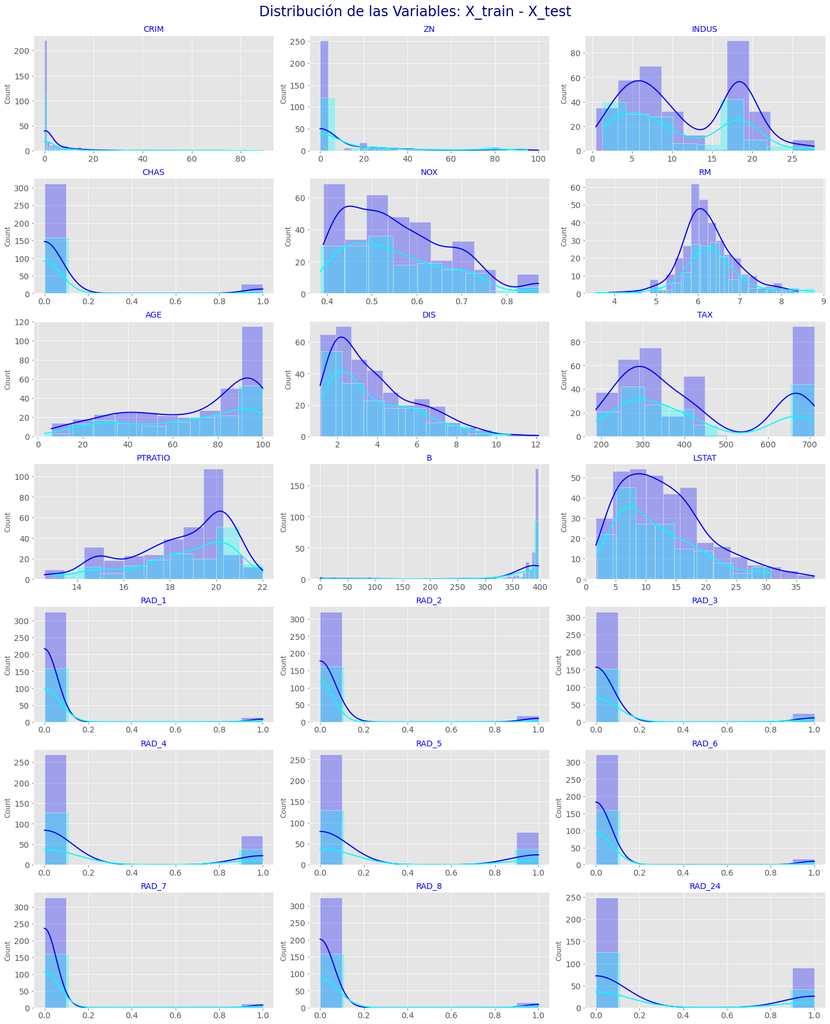

```python
# Distribución gráfica de cada variable de X_train
# ==============================================================================

fig, axes = plt.subplots(ncols=3, nrows=7, figsize=(20, 25))
axes = axes.flat
columnas_numeric = X_train.select_dtypes(include=['float64', 'int','uint8']).columns

for i, colum in enumerate(columnas_numeric):
    sns.histplot(data = X_train, x= colum, stat= "count",label="X_train", color="blue", kde = True, line_kws= {'linewidth': 2}, alpha   = 0.3, ax = axes[i])
    sns.histplot(data = X_test, x= colum, stat= "count", label= "X_test", color="cyan",kde = True, line_kws= {'linewidth': 2}, alpha   = 0.3, ax = axes[i])
    axes[i].set_title(colum, fontsize = 14, fontweight = "ultralight", color="blue")
    axes[i].tick_params(labelsize = 14)
    axes[i].set_xlabel("")

fig.tight_layout()
plt.subplots_adjust(top = 0.95)
plt.suptitle('Distribución de las Variables: X_train - X_test', fontsize = 24, color="navy",fontweight = "light")
plt.savefig("Gafico1_Dist_Variables_X_train_test.png")
```

- X_train -color navy, X_test - color cyan (* labels definidos pero no aparecen en la imagen)
- RM sigue claramente una distribución normal así como MEDV la variable objetivo.
- Las variables INDUS, RAS Y TAX siguen una distribución que se aproximan más a una distribución polinómica.
- LSTAT, AGE, DIS, PTRATIO y NOX se aproximan más a una distribución Gaussiana con sesgo
- El resto de variables CRIM, ZN, CHAS podrían ajustarse a exponenciales decrecientes o crecientes en el caso de B.

#### E.2) Student's t-test

- Un t-test de Student es una herramienta para evaluar las medias de uno o dos grupos mediante pruebas de hipótesis.
- Una prueba t puede usarse para determinar si un único grupo difiere de un valor conocido (una prueba t de una muestra) o bien, si dos grupos difieren entre sí (prueba t de muestras independientes), y finalmente si hay una diferencia significativa en medidas pareadas (una prueba t de muestras dependientes)
- En nuestro caso vamos a comparar si la variables LSTAT tienen la misma o diferente distribución para Los subgrupos X_train y X_test, para un nivel de significación= 5%

```python
print("====================")
print("  Student's t-test  ")
print("====================")
#from scipy.stats import ttest_ind
data1 = X_train["LSTAT"]
data2 = X_test["LSTAT"]
stat, p = ttest_ind(data1, data2)
print('stat=%.3f, p=%.3f' % (stat, p))
if p > 0.05:
    print('Probably the same distribution')
else:
    print('Probably different distributions')
```

```
====================
  Student's t-test
====================
stat=1.955, p=0.051
Probably the same distribution
```

- El resultado del test indica que las funciones de distribución de X_train y X_test de la variable LSTAT siguen la misma funciín de distribución

#### E.3) Mann-Whitney U Test

- La U de Mann-Whitney (también llamada de Mann-Whitney-Wilcoxon, prueba de suma de rangos Wilcoxon, o prueba de Wilcoxon-Mann-Whitney) es una prueba no paramétrica aplicada a dos muestras independientes.
- Es la versión no paramétrica de la habitual prueba t de Student y se usa para comprobar la heterogeneidad de dos muestras ordinales.
- Vamos a comparar las distribuciondes de la variable RM de las muestras X_train y X_test, para un p-value del 0,05%.

```python
print("=======================")
print("  Mann-Whitney U Test  ")
print("=======================")
#from scipy.stats import mannwhitneyu

data1 = X_train["RM"]
data2 = X_test["RM"]
stat, p = mannwhitneyu(data1, data2)
print('stat=%.3f, p=%.3f' % (stat, p))
if p > 0.05:
    print('Probably the same distribution')
else:
    print('Probably different distributions')
```

```
=======================
  Mann-Whitney U Test
=======================
stat=25399.000, p=0.060
Probably the same distribution
```

- El resultado del test indica que las funciones de distribución de X_train y X_test de la variable RM siguen la misma funciín de distribución

#### F) Escalado de la información y Elección de los Modelos

- El escalado se realiza para normalizar los datos de forma que no se dé prioridad a una característica concreta. El papel del escalado es muy importante en los algoritmos basados en la distancia y que requieren la distancia euclidiana.
- Sin empargo escalado, no es necesario para los modelos basados en árboles aleatorios y dado que los dos modelos que vamos a comparar son Decision Tree Regresor y Randon Forest Regressor el escalado no aporta más precisión al resultado de las métricas.
- Diferencias entre Árboles de decisión y modelos lineales:
  1. Si la relación entre la variable dependiente y la(s) independiente se aproxima a un modelo lineal, la regresión lineal dará mejores resultados que un modelo de árbol de decisión.
  2. Si la relación es compleja y altamente no lineal, entonces el árbol de decisión tendrá mejores resultados de que un método clásico de regresión.
  3. Si se quiere construir un modelo que sea fácil de explicar, entonces un modelo de árbol de decisión será mejor que un modelo lineal.
- En nuestro caso la variable objetivo MEDV y las variables explicativas tiene una relación compleja que se detalla en el estudio de Harrison, D. and Rubinfeld, D.L. - Hedonic prices and the demand for clean air, J. Environ. Economics & Management, vol.5, 81-102, 1978.-

#### G) Ajuste del modelo 1:

#### G.1) Modelo 1: Árboles de regresión

La clase DecisionTreeRegressor del módulo sklearn.tree permite entrenar árboles de decisión para problemas de regresión. Se ha ajustado un árbol de regresión empleando como variable respuesta MEDV y como predictores el resto de variables disponibles.

##### G.1.1) Creación y entrenamiento del Modelo 1

```python
# Creación del modelo
# ------------------------------------------------------------------------------
modelo1 = DecisionTreeRegressor(max_depth= 4,criterion="poisson", random_state = 123)

# Entrenamiento del modelo
# ------------------------------------------------------------------------------
modelo1.fit(X_train, y_train)
```

```
DecisionTreeRegressor(criterion='poisson', max_depth=4, random_state=123)
```

```python
# Error del modelo con train
#-------------------------------------------------------------------------------
y_pred = modelo1.predict(X = X_train)
```

```python
# Evaluación del modelo con train
#-------------------------------------------------------------------------------
mse_modelo1_train= metrics.mean_squared_error(y_train, y_pred)
rmse_modelo1_train= np.sqrt(metrics.mean_squared_error(y_train, y_pred))
rdt2_modelo1_train= metrics.r2_score(y_train, y_pred)
rdt2_modelo1_adj_train= 1 - (1-metrics.r2_score(y_train, y_pred))*(len(y_train)-1)/(len(y_train)-X_train.shape[1]-1)

print('MAE:',metrics.mean_absolute_error(y_train, y_pred))
print('MSE:',mse_modelo1_train)
print('RMSE:',rmse_modelo1_train,)
print('R^2:',rdt2_modelo1_train)
print('Adjusted R^2:',rdt2_modelo1_adj_train)
```

```
MAE: 2.2757502980583113
MSE: 9.262828213941626
RMSE: 3.0434894798473717
R^2: 0.8876539843050414
Adjusted R^2: 0.8802115037700441
```

```python
model_rdos_train =np.empty(shape=(0,4), dtype=float)
model_rdos_train = np.append(model_rdos_train ,[[mse_modelo1_train,rmse_modelo1_train,rdt2_modelo1_train,rdt2_modelo1_adj_train]],axis=0)
```

##### G.1.2) Error de test del modelo 1

```python
# Error de test del modelo
#-------------------------------------------------------------------------------
y_test_pred = modelo1.predict(X = X_test)
```

```python
# Evaluación del Modelo
# ==============================================================================
print('MAE:',metrics.mean_absolute_error(y_test, y_test_pred))
mse_modelo1=metrics.mean_squared_error(y_test, y_test_pred)
print('MSE:',mse_modelo1)
rmse_modelo1=np.sqrt(mse_modelo1)
print('RMSE:',rmse_modelo1)
rdt2_modelo1= metrics.r2_score(y_test, y_test_pred)
print('R^2:', rdt2_modelo1)
rdt2_modelo1_adj = 1 - (1-rdt2_modelo1)*(len(y_test)-1)/(len(y_test)-X_test.shape[1]-1)
print('Adjusted R^2:',rdt2_modelo1_adj)
```

```
MAE: 3.0352289044349186
MSE: 17.007864250526865
RMSE: 4.124059195807798
R^2: 0.8068533996424487
Adjusted R^2: 0.7788804437285965
```

```python
model_rdos=np.empty(shape=(0,4), dtype=float)
model_rdos= np.append(model_rdos,[[mse_modelo1,rmse_modelo1,rdt2_modelo1,rdt2_modelo1_adj]],axis=0)
```

##### G.1.3) Gráficos de modelo 1

```
Profundidad del árbol: 4
Número de nodos terminales: 15
```

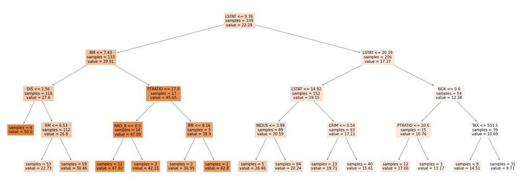

```python
# Estructura del árbol creado
# ------------------------------------------------------------------------------
fig, ax = plt.subplots(figsize=(25, 9))

print(f"Profundidad del árbol: {modelo1.get_depth()}")
print(f"Número de nodos terminales: {modelo1.get_n_leaves()}")

plot = plot_tree(
            decision_tree = modelo1,
            feature_names = df.drop(columns = "MEDV").columns,
            class_names   = 'MEDV',
            filled        = True,
            impurity      = False,
            fontsize      = 10,
            precision     = 2,
            ax            = ax
       )
```

##### G.1.4) Parámetros de los nodos del modelo 1

```python
texto_modelo = export_text(
                    decision_tree = modelo1,
                    feature_names = list(df.drop(columns = "MEDV").columns)
               )
print(texto_modelo)
```

```
|--- LSTAT <= 9.76
|   |--- RM <= 7.43
|   |   |--- DIS <= 1.56
|   |   |   |--- value: [50.00]
|   |   |--- DIS >  1.56
|   |   |   |--- RM <= 6.53
|   |   |   |   |--- value: [22.73]
|   |   |   |--- RM >  6.53
|   |   |   |   |--- value: [30.46]
|   |--- RM >  7.43
|   |   |--- PTRATIO <= 17.90
|   |   |   |--- RAD_8 <= 0.50
|   |   |   |   |--- value: [47.92]
|   |   |   |--- RAD_8 >  0.50
|   |   |   |   |--- value: [42.15]
|   |   |--- PTRATIO >  17.90
|   |   |   |--- RM <= 8.16
|   |   |   |   |--- value: [36.95]
|   |   |   |--- RM >  8.16
|   |   |   |   |--- value: [42.80]
|--- LSTAT >  9.76
|   |--- LSTAT <= 20.19
|   |   |--- LSTAT <= 14.92
|   |   |   |--- INDUS <= 3.99
|   |   |   |   |--- value: [26.46]
|   |   |   |--- INDUS >  3.99
|   |   |   |   |--- value: [20.24]
|   |   |--- LSTAT >  14.92
|   |   |   |--- CRIM <= 0.54
|   |   |   |   |--- value: [19.71]
|   |   |   |--- CRIM >  0.54
|   |   |   |   |--- value: [15.61]
|   |--- LSTAT >  20.19
|   |   |--- NOX <= 0.60
|   |   |   |--- PTRATIO <= 20.60
|   |   |   |   |--- value: [17.66]
|   |   |   |--- PTRATIO >  20.60
|   |   |   |   |--- value: [13.17]
|   |   |--- NOX >  0.60
|   |   |   |--- TAX <= 551.50
|   |   |   |   |--- value: [14.51]
|   |   |   |--- TAX >  551.50
|   |   |   |   |--- value: [9.71]
```

- El modelo predice un valor promedio de MEDV de 50.000 dólares para viviendas que están en una zona con un LSTAT <= 9.76, un RM<= 7.43 y un DIS <= 1.56
- El rmse de test implica que las predicciones del modelo se alejan en promedio 4.124 dólares del valor real

##### G.1.5) Importancia de los predictores

```python
importancia_predictores = pd.DataFrame(
                            {'predictor': df.drop(columns = "MEDV").columns,
                             'importancia': modelo1.feature_importances_}
                            )
print("Importancia de los predictores en el modelo")
print("-------------------------------------------")
importancia_predictores.sort_values('importancia', ascending=False)
```

```
Importancia de los predictores en el modelo
-------------------------------------------
```

|  | predictor | importancia |
| --- | --- | --- |
| 11 | LSTAT | 0.670051 |
| 5 | RM | 0.199536 |
| 7 | DIS | 0.059288 |
| 4 | NOX | 0.029380 |
| 0 | CRIM | 0.013650 |
| 8 | TAX | 0.012320 |
| 2 | INDUS | 0.007919 |
| 9 | PTRATIO | 0.006645 |
| 19 | RAD_8 | 0.001211 |
| 14 | RAD_3 | 0.000000 |
| 18 | RAD_7 | 0.000000 |
| 17 | RAD_6 | 0.000000 |
| 16 | RAD_5 | 0.000000 |
| 15 | RAD_4 | 0.000000 |
| 10 | B | 0.000000 |
| 13 | RAD_2 | 0.000000 |
| 12 | RAD_1 | 0.000000 |
| 1 | ZN | 0.000000 |
| 6 | AGE | 0.000000 |
| 3 | CHAS | 0.000000 |
| 20 | RAD_24 | 0.000000 |

- El predictor LSTAT, que es un índice en porcentaje de las personas en situación de pobreza, ha resultado se en este caso ser el predictor más importante del modelo, seguido de RM que es el número medio de habitaciones en las viviendas de la zona.

#### H) Ajuste del modelo 2

Se ajusta un modelo empleando como variable respuesta MEDV y como predictores todas las otras variables disponibles. La clase RandomForestRegressor del módulo sklearn.ensemble permite entrenar modelos random forest para problemas de regresión

##### H.1.1) Creación y entrenamiento del Modelo 2

```python
# Creación del modelo
# ==============================================================================
modelo2 = RandomForestRegressor(random_state=123)

# Entrenamiento del modelo
# ==============================================================================
modelo2.fit(X_train, y_train)
```

```
RandomForestRegressor(random_state=123)
```

```python
# Model prediction on train data
y_pred = modelo2.predict(X_train)
```

```python
# Evaluación del modelo con train
#-------------------------------------------------------------------------------
mse_modelo2_train= metrics.mean_squared_error(y_train, y_pred)
rmse_modelo2_train= np.sqrt(metrics.mean_squared_error(y_train, y_pred))
rdt2_modelo2_train= metrics.r2_score(y_train, y_pred)
rdt2_modelo2_adj_train= 1 - (1-metrics.r2_score(y_train, y_pred))*(len(y_train)-1)/(len(y_train)-X_train.shape[1]-1)

print('MAE:',metrics.mean_absolute_error(y_train, y_pred))
print('MSE:',mse_modelo2_train)
print('RMSE:',rmse_modelo2_train,)
print('R^2:',rdt2_modelo2_train)
print('Adjusted R^2:',rdt2_modelo2_adj_train)
```

```
MAE: 0.8532241887905595
MSE: 1.5780336312684342
RMSE: 1.2561980859993516
R^2: 0.9808605118209123
Adjusted R^2: 0.9795925962002157
```

```python
model_rdos_train = np.append(model_rdos_train ,[[mse_modelo2_train,rmse_modelo2_train,rdt2_modelo2_train,rdt2_modelo2_adj_train]],axis=0)
```

##### H.1.2) Error de test del modelo 2

```python
# Predicciones con Test data
# ==============================================================================
y_test_pred = modelo2.predict(X_test)
```

```python
# Evaluación del Modelo
# ==============================================================================
print('MAE:',metrics.mean_absolute_error(y_test, y_test_pred))
mse_modelo2=metrics.mean_squared_error(y_test, y_test_pred)
print('MSE:',mse_modelo2)
rmse_modelo2=np.sqrt(mse_modelo2)
print('RMSE:',rmse_modelo2)
rdt2_modelo2= metrics.r2_score(y_test, y_test_pred)
print('R^2:',rdt2_modelo2 )
rdt2_modelo2_adj = 1 - (1-rdt2_modelo2)*(len(y_test)-1)/(len(y_test)-X_test.shape[1]-1)
print('Adjusted R^2:',rdt2_modelo2_adj)
```

```
MAE: 2.2382275449101794
MSE: 9.695962766467066
RMSE: 3.1138340942425087
R^2: 0.8898896288240014
Adjusted R^2: 0.8739426095502361
```

```python
model_rdos= np.append(model_rdos,[[mse_modelo2,rmse_modelo2,rdt2_modelo2,rdt2_modelo2_adj]],axis=0)
```

- En este caso el modelo Randon Forest Regressor tiene un rmse de test implica que las predicciones del modelo se alejan en promedio 3.114 dólares del valor real, y es inferior al del modelo 1.

##### H.1.3) Importancia de los predictores

```python
importancia_predictores = pd.DataFrame(
                            {'predictor': df.drop(columns = "MEDV").columns,
                             'importancia': modelo2.feature_importances_}
                            )
print("Importancia de los predictores en el modelo")
print("-------------------------------------------")
importancia_predictores.sort_values('importancia', ascending=False)
```

```
Importancia de los predictores en el modelo
-------------------------------------------
```

|  | predictor | importancia |
| --- | --- | --- |
| 11 | LSTAT | 0.595458 |
| 5 | RM | 0.197957 |
| 7 | DIS | 0.066939 |
| 0 | CRIM | 0.038028 |
| 4 | NOX | 0.023147 |
| 6 | AGE | 0.020468 |
| 9 | PTRATIO | 0.014740 |
| 10 | B | 0.014207 |
| 8 | TAX | 0.011835 |
| 2 | INDUS | 0.009619 |
| 16 | RAD_5 | 0.001119 |
| 1 | ZN | 0.001065 |
| 3 | CHAS | 0.000991 |
| 12 | RAD_1 | 0.000980 |
| 19 | RAD_8 | 0.000762 |
| 20 | RAD_24 | 0.000693 |
| 13 | RAD_2 | 0.000512 |
| 15 | RAD_4 | 0.000471 |
| 14 | RAD_3 | 0.000394 |
| 17 | RAD_6 | 0.000358 |
| 18 | RAD_7 | 0.000255 |

- En cuanto a la importancia de los predictores se mantienen en los primeros lugares los mismos que en el modelo anterior, pero en este caso Randon Forest Regressor sí pondera y utiliza todas las variables, por lo que asigna valor a todos los predictores.

## Exercici 2

#### Compara’ls en base al MSE i al R2.

#### A) Definición y significado de MSE

- La métrica más comúnmente utilizada para las tareas de regresión es el error cuadrático medio (MSE) y representa a la raíz cuadrada de la distancia al cuadrado del promedio entre el valor real y el valor pronosticado.
- Indica el ajuste absoluto del modelo a los datos, cuán cerca están los puntos de datos observados de los valores predichos por el modelo. El error cuadratico medio o MSE es una medida absoluta de ajuste.
- RMSE (Root Mean Squared Error) o raíz cuadrada del error cuadrático medio (MSE), se puede interpretar como la desviación estándar de la varianza inexplicada, y tiene la propiedad de estar en las mismas unidades que la variable de respuesta.
- Cuanto más bajos más bajos son los valores de MSE y RMSE mejor es el ajuste del modelo.
- MSE y RMSE son buenas medidas de la precisión con que el modelo realiza una predicción, y suelen ser el criterio más importante para ajustar si el propósito principal del modelo es la predicción.

#### B) Definición y significado de R2

- El coeficiente de determinación es la proporción de la varianza total de la variable explicada por la regresión. El coeficiente de determinación, también llamado R cuadrado, refleja la bondad del ajuste de un modelo a la variable que pretender explicar.
- El resultado del coeficiente de determinación oscila entre 0 y 1. Cuanto más cerca de 1 se sitúe su valor, mayor será el ajuste del modelo a la variable que estamos intentando explicar. De forma inversa, cuanto más cerca de cero, menos ajustado estará el modelo y, por tanto, menos fiable será
- El problema del coeficiente de determinación, y razón por el cual surge el coeficiente de determinación ajustado, radica en que no penaliza la inclusión de variables explicativas no significativas.
- El coeficiente de determinación ajustado (R cuadrado ajustado) es la medida que define el porcentaje explicado por la varianza de la regresión en relación con la varianza de la variable explicada, por tanto penaliza la inclusión de nuevas variables.

#### C) Sumario de Metricas

##### C.1) Métricas sobre Train

```python
row_indices = ["Modelo 1: Decision Tree Regressor", "Modelo 2: Random Forest Regressor"]
column_names = ["MSE","RMSE", "R^2","R^2 Ajustado"]
resultados = pd.DataFrame(model_rdos_train, index=row_indices,columns=column_names)
resultados
```

|  | MSE | RMSE | R^2 | R^2 Ajustado |
| --- | --- | --- | --- | --- |
| Modelo 1: Decision Tree Regressor | 9.262828 | 3.043489 | 0.887654 | 0.880212 |
| Modelo 2: Random Forest Regressor | 1.578034 | 1.256198 | 0.980861 | 0.979593 |

- El modelo 1 Decision Tree Regressor, tiene unos valores superiores de RMSE e inferiores de R^2 al modelo 2, cuando aplicamos la predccion sobre train.
- El RMSE es de 3.043 dólares y se corresponde con la desviadcion en promedio de las preciciones en relación al valor real de la variable objetivo MEDV (valor de las viviendas en Boston), mientras que el ajuste del modelo R^2 es el 88,76%
- El modelo 2 Random Forest Regressor, aporta mejores métricas tanto en RMSE como en R^2, con una desviación media del valor de las preccciones de 1.256 dólares y un nivel de ajuste del 98,08%

##### C.2) Métricas sobre Test

```python
row_indices = ["Modelo 1: Decision Tree Regressor", "Modelo 2: Random Forest Regressor"]
column_names = ["MSE","RMSE", "R^2","R^2 Ajustado"]
resultados = pd.DataFrame(model_rdos, index=row_indices,columns=column_names)
resultados
```

|  | MSE | RMSE | R^2 | R^2 Ajustado |
| --- | --- | --- | --- | --- |
| Modelo 1: Decision Tree Regressor | 17.007864 | 4.124059 | 0.806853 | 0.778880 |
| Modelo 2: Random Forest Regressor | 9.695963 | 3.113834 | 0.889890 | 0.873943 |

- El modelo 1 Decision Tree Regressor, tiene unos valores superiores de RMSE e inferiores de R^2 al modelo 2, cuando aplicamos la predccion sobre test.
- El RMSE es de 4.124 dólares y es la desviadcion en promedio de las preciciones en relación al valor real de la variable objetivo MEDV, mientras que el ajuste del modelo R^2 es del 80,68%
- El modelo 2 Random Forest Regressor, aporta mejores métricas tanto en RMSE como en R^2, con una desviación media del valor de las preccciones de 3.113 dólares y un novel de ajuste del 88,98%

## Exercici 3

#### Entrena’ls utilitzant els diferents paràmetres que admeten per intentar millorar-ne la predicció.

#### 3.1. Modificación parámetros del modelo DecisionTreeRegressor - modelo 3

```python
DecisionTreeRegressor().get_params().keys()
```

```
dict_keys(['ccp_alpha', 'criterion', 'max_depth', 'max_features', 'max_leaf_nodes', 'min_impurity_decrease', 'min_samples_leaf', 'min_samples_split', 'min_weight_fraction_leaf', 'random_state', 'splitter'])
```

```python
# Grid de hiperparámetros evaluados
# ==============================================================================
param_grid = {'criterion': ["squared_error", "friedman_mse", "absolute_error", "poisson"],
              'max_features': ["auto", "sqrt", "log2", None],
              'splitter': ["best", "random"]
             }

# cross validator
# ==============================================================================
cv= RepeatedKFold(n_splits=10, n_repeats=3, random_state=123)

# Búsqueda por grid search con validación cruzada
# ==============================================================================
grid = GridSearchCV(
        estimator  = DecisionTreeRegressor(max_depth= 4,random_state = 123),
        param_grid = param_grid,
        scoring    = 'neg_median_absolute_error',
        n_jobs     = multiprocessing.cpu_count() - 1,
        cv         = cv,
        refit      = True,
        verbose    = 0,
        return_train_score = True
       )

result= grid.fit(X = X_train, y = y_train)

print('Best Hyperparameters: ', result.best_params_)
```

```
Best Hyperparameters:  {'criterion': 'absolute_error', 'max_features': 'auto', 'splitter': 'best'}
```

```python
# # Repetición del modelo con Best Hyperparameters
# ------------------------------------------------------------------------------
modelo3 = DecisionTreeRegressor(max_depth= 4,random_state = 123, criterion="absolute_error",  max_features = "auto", splitter="best")

# Entrenamiento del modelo
# ------------------------------------------------------------------------------
modelo3.fit(X_train, y_train)
```

```
DecisionTreeRegressor(criterion='absolute_error', max_depth=4,
                      max_features='auto', random_state=123)
```

```python
# Error de test del modelo
#-------------------------------------------------------------------------------
y_predicciones = modelo3.predict(X = X_test)

print('MAE:', metrics.mean_absolute_error(y_test, y_predicciones))

mse_modelo3=metrics.mean_squared_error(y_test, y_predicciones)
print('MSE:',mse_modelo3)

rmse_modelo3=np.sqrt(mse_modelo3)
print('RMSE:',rmse_modelo3)

#R2 for the decision tree regression model
rdt2_modelo3= metrics.r2_score(y_test, y_predicciones)
print('R^2:', rdt2_modelo3)

rdt2_modelo3_adj = 1 - (1-rdt2_modelo3)*(len(y_test)-1)/(len(y_test)-X_test.shape[1]-1)
print('Adjusted R^2:',rdt2_modelo3_adj)
```

```
MAE: 2.9970059880239512
MSE: 19.59494011976048
RMSE: 4.426617232126636
R^2: 0.7774737608089574
Adjusted R^2: 0.7452458227192202
```

```python
model_rdos= np.append(model_rdos,[[mse_modelo3,rmse_modelo3,rdt2_modelo3,rdt2_modelo3_adj]],axis=0)
```

- Con esta combinación de parámetros sobre el modelo de Decision Tree Regressor las métricas de RMSE y R^2 empeoran respecto al modelo 1

#### 3.1.2. Modificación parámetros del modelo DecisionTreeRegressor - modelo 4

```python
grid = GridSearchCV(DecisionTreeRegressor(), param_grid, scoring = 'neg_mean_squared_error', n_jobs = -1, cv = cv)
result = grid.fit(X_train, y_train)

print('Best Hyperparameters: ', result.best_params_)
```

```
Best Hyperparameters:  {'criterion': 'squared_error', 'max_features': 'auto', 'splitter': 'best'}
```

```python
# Creación del modelo
# ------------------------------------------------------------------------------
modelo4 = DecisionTreeRegressor(max_depth= 4,random_state = 123, criterion="squared_error",  max_features = None, splitter="best")

# Entrenamiento del modelo
# ------------------------------------------------------------------------------
modelo4.fit(X_train, y_train)
```

```
DecisionTreeRegressor(max_depth=4, random_state=123)
```

```python
# Error de test del modelo
#-------------------------------------------------------------------------------
y_predicciones = modelo4.predict(X = X_test)

print('MAE:', metrics.mean_absolute_error(y_test, y_predicciones))


mse_modelo4=metrics.mean_squared_error(y_test, y_predicciones)
print('MSE:',mse_modelo4)

rmse_modelo4=np.sqrt(mse_modelo4)
print('RMSE:',rmse_modelo4)

#R2 for the decision tree regression model
rdt2_modelo4= metrics.r2_score(y_test, y_predicciones )
print('R^2:', rdt2_modelo4)

#R2 Ajusted for the decision tree regression model
rdt2_modelo4_adj = 1 - (1-rdt2_modelo4)*(len(y_test)-1)/(len(y_test)-X_test.shape[1]-1)
print('Adjusted R^2:',rdt2_modelo4_adj)
```

```
MAE: 2.849673566949767
MSE: 15.074854351517601
RMSE: 3.8826349753122043
R^2: 0.8288052617311626
Adjusted R^2: 0.8040115410163655
```

```python
model_rdos= np.append(model_rdos,[[mse_modelo4,rmse_modelo4,rdt2_modelo4,rdt2_modelo4_adj]],axis=0)
```

#### 3.2. Modificación parámetros del modelo RandomForestRegressor - modelo 5

```python
RandomForestRegressor().get_params().keys()
```

```
dict_keys(['bootstrap', 'ccp_alpha', 'criterion', 'max_depth', 'max_features', 'max_leaf_nodes', 'max_samples', 'min_impurity_decrease', 'min_samples_leaf', 'min_samples_split', 'min_weight_fraction_leaf', 'n_estimators', 'n_jobs', 'oob_score', 'random_state', 'verbose', 'warm_start'])
```

```python
modelo_rf = RandomForestRegressor(random_state = 123)
print('Parameters currently in use:\n')
pprint(modelo_rf.get_params())
```

```
Parameters currently in use:

{'bootstrap': True,
 'ccp_alpha': 0.0,
 'criterion': 'squared_error',
 'max_depth': None,
 'max_features': 1.0,
 'max_leaf_nodes': None,
 'max_samples': None,
 'min_impurity_decrease': 0.0,
 'min_samples_leaf': 1,
 'min_samples_split': 2,
 'min_weight_fraction_leaf': 0.0,
 'n_estimators': 100,
 'n_jobs': None,
 'oob_score': False,
 'random_state': 123,
 'verbose': 0,
 'warm_start': False}
```

```python
# Grid de hiperparámetros evaluados
# ==============================================================================
param_grid = {'n_estimators': [150],
              'max_features': [5, 7, 9],
              'max_depth'   : [None, 3, 10, 20]
             }
# cross validator
# ==============================================================================
cv= RepeatedKFold(n_splits=10, n_repeats=3, random_state=123)

# Búsqueda por grid search con validación cruzada
# ==============================================================================
grid = GridSearchCV(
        estimator  = RandomForestRegressor(random_state = 123),
        param_grid = param_grid,
        scoring    = 'neg_mean_squared_error',
        n_jobs     = multiprocessing.cpu_count() - 1,
        cv         = cv,
        refit      = True,
        verbose    = 0,
        return_train_score = True
       )

result= grid.fit(X = X_train, y = y_train)

print('Best Hyperparameters: ', result.best_params_)
```

```
Best Hyperparameters:  {'max_depth': 20, 'max_features': 9, 'n_estimators': 150}
```

```python
# Repetición del modelo con Best Hyperparameters
# ==============================================================================
modelo5 = RandomForestRegressor(max_depth= 20, max_features= 9, n_estimators= 150,random_state=123)

# Entrenamiento del modelo
# ==============================================================================
modelo5.fit(X_train, y_train)
```

```
RandomForestRegressor(max_depth=20, max_features=9, n_estimators=150,
                      random_state=123)
```

```python
# Predicciones
# ==============================================================================
y_predicciones = modelo5.predict(X_test)

# Evaluación de las predicciones
# ==============================================================================

print('MAE:', metrics.mean_absolute_error(y_test, y_predicciones))

mse_modelo5=metrics.mean_squared_error(y_test, y_predicciones)
print('MSE:',mse_modelo5)

rmse_modelo5=np.sqrt(mse_modelo5)
print('RMSE:',rmse_modelo5)

#R2 for the Randon Forest Regression model
rdt2_modelo5= metrics.r2_score(y_test, y_predicciones )
print('R^2:', rdt2_modelo5)

#R2 Ajusted for the Randon Forest Regression model
rdt2_modelo5_adj = 1 - (1-rdt2_modelo5)*(len(y_test)-1)/(len(y_test)-X_test.shape[1]-1)
print('Adjusted R^2:',rdt2_modelo5_adj)
```

```
MAE: 2.248965529546966
MSE: 9.143771699685777
RMSE: 3.0238670109126455
R^2: 0.8961604824553332
Adjusted R^2: 0.8811216557764504
```

```python
model_rdos= np.append(model_rdos,[[mse_modelo5,rmse_modelo5,rdt2_modelo5,rdt2_modelo5_adj]],axis=0)
```

#### C) Sumary de resultados sobre test

```python
row_indices = ["M_1: Decision Tree Regressor", "M_2: Random Forest Regressor","M_3: DecisionTreeRegressor v1","M_4: DecisionTreeRegressor v2","M_5: RandomForestRegressor"]
column_names = ["MSE", "RMSE", "R^2","R^2 Ajustado"]
resultados = pd.DataFrame(model_rdos, index=row_indices,columns=column_names)
resultados.sort_values(by="MSE")
```

|  | MSE | RMSE | R^2 | R^2 Ajustado |
| --- | --- | --- | --- | --- |
| M_5: RandomForestRegressor | 9.143772 | 3.023867 | 0.896160 | 0.881122 |
| M_2: Random Forest Regressor | 9.695963 | 3.113834 | 0.889890 | 0.873943 |
| M_4: DecisionTreeRegressor v2 | 15.074854 | 3.882635 | 0.828805 | 0.804012 |
| M_1: Decision Tree Regressor | 17.007864 | 4.124059 | 0.806853 | 0.778880 |
| M_3: DecisionTreeRegressor v1 | 19.594940 | 4.426617 | 0.777474 | 0.745246 |

- El modelo que tiene mejores métricas de MSE, RMSE y R^2 es el modelo 5 Random Forest REgressor con los parámetros optimizados, con un RMSE de 3.023 dólares y un R^" del 89,61%
- En todos los casos evaluados el Modelo Randon Fores proporciona mejores métricas que el Decision Tree Reressor.

## Exercici 4

#### Compara el seu rendiment emprant l’aproximació traint/test o emprant totes les dades (validació interna).

No existe un método de validación que supere al resto en todos los escenarios, la elección debe basarse en varios factores.

- Si el tamaño de la muestra es pequeño, se recomienda emplear repeated k-Fold-Cross-Validation, ya que consigue un buen equilibrio bias-varianza y, dado que no son muchas observaciones, el coste computacional no es excesivo.
- Si el objetivo principal es comparar modelos mas que obtener una estimación precisa de las métricas, se recomienda bootstrapping ya que tiene menos varianza.
- Si el tamaño muestral es muy grande, la diferencia entre métodos se reduce y toma más importancia la eficiencia computacional. En estos casos, 10-Fold-Cross-Validation simple es suficiente.

#### 4.1. Validación cruzada del modelo DecisionTreeRegressor - modelo 4

```python
X_todos= df.drop(columns = "MEDV")
y_todos=df['MEDV']
```

##### a) Métricas de la Validación Cruzada

```python
# Validación cruzada
# ==============================================================================
cv = KFold(n_splits=10, random_state=123, shuffle=True)

modelo4_r2_scores = cross_val_score(modelo4, X_todos, y_todos, cv = cv, scoring="r2")
modelo4_r2_mean = np.mean(modelo4_r2_scores)
modelo4_mse_scores = cross_val_score(modelo4, X_todos, y_todos, cv = cv,scoring = "neg_mean_absolute_error")
modelo4_mse_media= abs(np.mean(modelo4_mse_scores))
modelo4_rmse=np.sqrt(modelo4_mse_media)

print("1. MSE de cada n-splits: ", modelo4_mse_scores)
print("2. MSE media: ",modelo4_mse_media)
print("3. RMSE: ",modelo4_rmse)
print("4. R^2 de cada n_splits", modelo4_r2_scores)
print("5. R^2 media :" ,modelo4_r2_mean)
```

```
1. MSE de cada n-splits:  [-5.07675102 -2.11582928 -3.39685357 -3.52465817 -2.53845558 -2.76811448
 -2.53979365 -2.44844316 -2.58481892 -2.98084804]
2. MSE media:  2.997456587102096
3. RMSE:  1.7313164318235115
4. R^2 de cada n_splits [0.26972536 0.84200914 0.67575511 0.7783927  0.87789799 0.85749317
 0.87129532 0.81322367 0.8801674  0.79580763]
5. R^2 media : 0.7661767488306064
```

```python
model_rdos_cruzados=np.empty(shape=(0,3), dtype=float)
model_rdos_cruzados= np.append(model_rdos_cruzados,[[modelo4_mse_media,modelo4_rmse,modelo4_r2_mean]],axis=0)
```

##### b) Gráficos - Diagnóstico errores (residuos) de las predicciones de validación cruzada

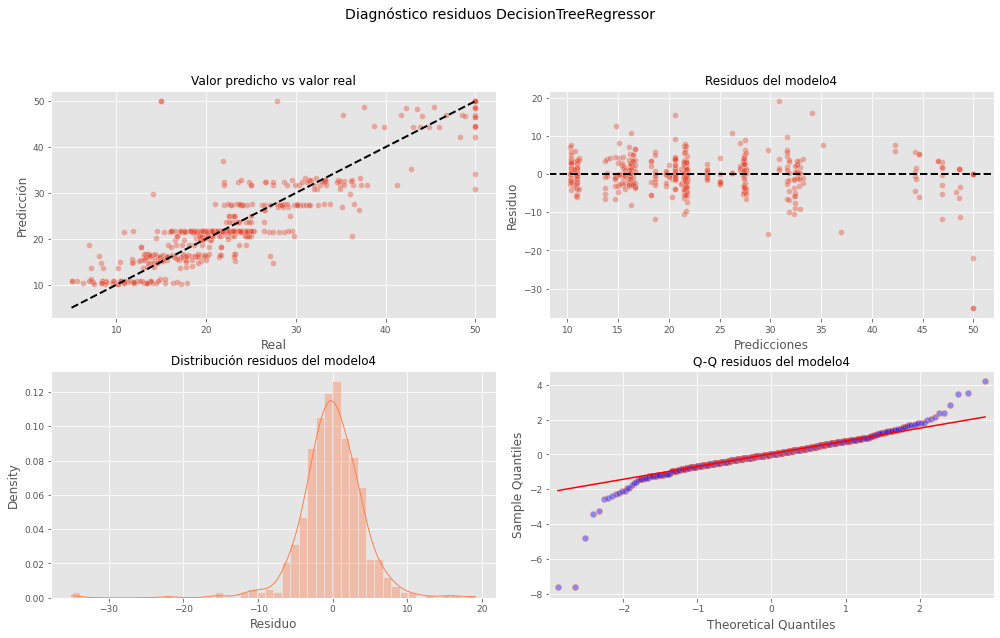

```python
# Gráficos :Diagnóstico errores (residuos) de las predicciones de validación cruzada
# ==================================================================================

cv_predicciones = cross_val_predict(estimator = modelo4, X = X_todos, y = y_todos, cv = cv)

fig, axes = plt.subplots(nrows=2, ncols=2, figsize=(14, 9))

axes[0, 0].scatter(y_todos, cv_predicciones, edgecolors=(1, 1, 1), alpha = 0.4)
axes[0, 0].plot([y_todos.min(), y_todos.max()], [y_todos.min(), y_todos.max()],'k--', color = 'black', lw=2)
axes[0, 0].set_title('Valor predicho vs valor real', fontsize = 12, fontweight = "normal")
axes[0, 0].set_xlabel('Real')
axes[0, 0].set_ylabel('Predicción')
axes[0, 0].tick_params(labelsize = 9)

axes[0, 1].scatter(cv_predicciones, y_todos - cv_predicciones, edgecolors=(1, 1, 1), alpha = 0.4)
axes[0, 1].axhline(y = 0, linestyle = '--', color = 'black', lw=2)
axes[0, 1].set_title('Residuos del modelo4', fontsize = 12, fontweight = "normal")
axes[0, 1].set_xlabel('Predicciones')
axes[0, 1].set_ylabel('Residuo')
axes[0, 1].tick_params(labelsize = 9)

sns.histplot(data  = y_todos - cv_predicciones, stat  = "density", kde = True, line_kws= {'linewidth': 1}, color = "coral", alpha = 0.4, ax = axes[1, 0])

axes[1, 0].set_title('Distribución residuos del modelo4', fontsize = 12, fontweight = "normal")
axes[1, 0].set_xlabel("Residuo")
axes[1, 0].tick_params(labelsize = 9)

sm.qqplot( y_todos - cv_predicciones, fit = True, line = 'q', ax = axes[1, 1], color = 'coral', alpha = 0.4, lw = 2)
axes[1, 1].set_title('Q-Q residuos del modelo4', fontsize = 12, fontweight = "normal")
axes[1, 1].tick_params(labelsize = 9)

fig.tight_layout()
plt.subplots_adjust(top=0.85)
fig.suptitle('Diagnóstico residuos DecisionTreeRegressor', fontsize = 14, fontweight = "normal")
```

- El análisis gráfico de los errores (residuos) de las precciones sobre la validación cruzada reflejan que la función de distribución se aproxima a la normal
- Sin embargo, el gráfico de residuos vs. predicciones se observa que los errores son más grades cuanto mayor el el valor de la predicción de la variable objetivo.
- Este mimo efecto se observa en la gráfica qqplot donde las colas de los valores inferiores y superiores se alejan de los valores teóricos.
- Como conclusión el modelo se ajusta bien en los valores centrales de la variable objetivo, pero pierde precisión en los valores más extremos, tienen problemas de dispersión irregular.
- En todos los casos la varianza de los residuos aumenta con los valores ajustados, esto indica que la variabilidad de los errores aumenta al aumentar su media y que es un tema que ya se detectó al analizar los outliers de la variable objetivo MEDV.
- Para mejorar estos resultados se podría utilizar pruebas de igualdad de varianza (complementarias a los análisis gráficos), considera utilizar transformaciones de las variables o modelar la heterogeneidad encontrada con modelos generalizados (GLM) o modelos mixtos (MM).

#### 4.2. Validación cruzada del modelo RandomForestRegressor - modelo 5

##### a) Métricas de la Validación Cruzada

```python
# Validación cruzada
# ==============================================================================
cv = KFold(n_splits=10, random_state=123, shuffle=True)

modelo5_r2_scores = cross_val_score(modelo5, X_todos, y_todos, cv = cv,scoring="r2")
modelo5_r2_mean = np.mean(modelo5_r2_scores)
modelo5_mse_scores = cross_val_score(modelo5, X_todos, y_todos, cv = cv,scoring = "neg_mean_absolute_error")
modelo5_mse_media= abs(np.mean(modelo5_mse_scores))
modelo5_rmse=np.sqrt(modelo5_mse_media)

print("1. MSE de cada n-splits: ", modelo5_mse_scores)
print("2. MSE media: ",modelo5_mse_media)
print("3. RMSE: ",modelo5_rmse)
print("4. R^2 de cada n_splits", modelo5_r2_scores)
print("5. R^2 media :" ,modelo5_r2_mean)
```

```
1. MSE de cada n-splits:  [-2.8704344  -1.49927015 -2.26853354 -2.48655241 -1.60721419 -2.31470733
 -2.01709129 -1.62067946 -2.22029178 -1.90924541]
2. MSE media:  2.0814019959305696
3. RMSE:  1.4427064829446665
4. R^2 de cada n_splits [0.79975471 0.90198632 0.8810006  0.88085156 0.94696826 0.8935899
 0.93050628 0.91295743 0.85526213 0.91034536]
5. R^2 media : 0.8913222554309324
```

```python
model_rdos_cruzados= np.append(model_rdos_cruzados,[[modelo5_mse_media,modelo5_rmse, modelo5_r2_mean]],axis=0)
```

##### b) Gráficos - Diagnóstico errores (residuos) de las predicciones de validación cruzada

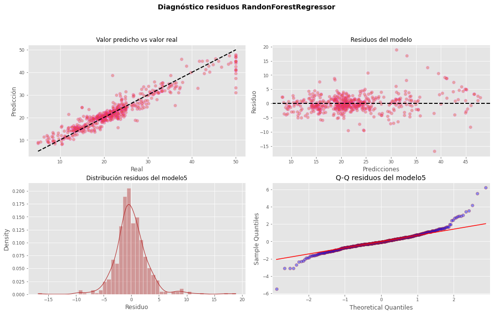

```python
# Gráficos: Diagnóstico errores (residuos) de las predicciones de validación cruzada
# ==================================================================================
cv_predicciones = cross_val_predict(estimator = modelo5, X = X_todos, y = y_todos, cv = cv)

fig, axes = plt.subplots(nrows=2, ncols=2, figsize=(14, 9))

axes[0, 0].scatter(y_todos, cv_predicciones, edgecolors=(1, 0, 1), alpha = 0.4)
axes[0, 0].plot([y_todos.min(), y_todos.max()], [y_todos.min(), y_todos.max()],'k--', color = 'black', lw=2)
axes[0, 0].set_title('Valor predicho vs valor real', fontsize = 12, fontweight = "normal")
axes[0, 0].set_xlabel('Real')
axes[0, 0].set_ylabel('Predicción')
axes[0, 0].tick_params(labelsize = 9)

axes[0, 1].scatter(cv_predicciones, y_todos - cv_predicciones, edgecolors=(1, 0, 1), alpha = 0.4)
axes[0, 1].axhline(y = 0, linestyle = '--', color = 'black', lw=2)
axes[0, 1].set_title('Residuos del modelo', fontsize = 12, fontweight = "normal")
axes[0, 1].set_xlabel('Predicciones')
axes[0, 1].set_ylabel('Residuo')
axes[0, 1].tick_params(labelsize = 9)

sns.histplot(data = y_todos - cv_predicciones,stat = "density",kde  = True,line_kws= {'linewidth': 1},color = "firebrick",alpha = 0.4, ax = axes[1, 0])

axes[1, 0].set_title('Distribución residuos del modelo5', fontsize = 12,fontweight = "normal")
axes[1, 0].set_xlabel("Residuo")
axes[1, 0].tick_params(labelsize = 9)


sm.qqplot( y_todos - cv_predicciones, fit = True, line  = 'q', ax  = axes[1, 1], color = 'firebrick',alpha = 0.4, lw = 2)
axes[1, 1].set_title('Q-Q residuos del modelo5', fontsize = 14, fontweight = "normal")
axes[1, 1].tick_params(labelsize = 9)

fig.tight_layout()
plt.subplots_adjust(top=0.85)
fig.suptitle('Diagnóstico residuos RandonForestRegressor', fontsize = 14, fontweight = "bold");
```

- En el modelo 5 Randon Forest Regressor, el análisis gráfico de los errores (residuos) de las precciones sobre la validación cruzada reflejan que la función de distribución se aproxima a la normal y con mayor precisión que el modelo anterior, al concentrar los errores en una rango de [-5, a 5], mientras que en el Modelo 4 Decision Tree Regressor el rango es de [-10 a 10] aproximadamente.
- El gráfico de residuos vs. predicciones se observa que los errores son más grades cuanto mayor el el valor de la predicción de la variable objetivo.
- Este mismo efecto se observa en la gráfica qqplot donde las colas de los valores inferiores y superiores se alejan de los valores teóricos.
- Como conclusión el modelo se ajusta bien en los valores centrales de la variable objetivo, pero pierde precisión en los valores más extremos, tienen problemas de dispersión irregular.
- En todos los casos la varianza de los residuos aumenta con los valores ajustados, esto indica que la variabilidad de los errores aumenta al aumentar su media como ya se preveía al analizar los outliers de la variable objetivo MEDV.
- Para mejorar estos resultados se podría utilizar pruebas de igualdad de varianza (complementarias a los análisis gráficos), considera utilizar transformaciones de las variables o modelar la heterogeneidad encontrada con modelos generalizados (GLM) o modelos mixtos (MM).

#### 4.3 Sumario Méticas de Validación Cruzada

```python
row_indices = ["Modelo 4: Decision Tree Regressor", "Modelo 5: Random Forest Regressor"]
column_names = ["MSE","RMSE", "R^2"]
resultados1 = pd.DataFrame(model_rdos_cruzados, index=row_indices,columns=column_names)
resultados1.sort_values(by="MSE")
```

[output not shown]

## Exercici 5

#### No facis servir la variable del nombre d'habitacions (RM) a l’hora de fer prediccions.

```python
data.head()
```

|  | CRIM | ZN | INDUS | CHAS | NOX | RM | AGE | DIS | RAD | TAX | PTRATIO | B | LSTAT | MEDV |
| --- | --- | --- | --- | --- | --- | --- | --- | --- | --- | --- | --- | --- | --- | --- |
| 0 | 0.00632 | 18.0 | 2.31 | 0 | 0.538 | 6.575 | 65.2 | 4.0900 | 1 | 296.0 | 15.3 | 396.90 | 4.98 | 24.0 |
| 1 | 0.02731 | 0.0 | 7.07 | 0 | 0.469 | 6.421 | 78.9 | 4.9671 | 2 | 242.0 | 17.8 | 396.90 | 9.14 | 21.6 |
| 2 | 0.02729 | 0.0 | 7.07 | 0 | 0.469 | 7.185 | 61.1 | 4.9671 | 2 | 242.0 | 17.8 | 392.83 | 4.03 | 34.7 |
| 3 | 0.03237 | 0.0 | 2.18 | 0 | 0.458 | 6.998 | 45.8 | 6.0622 | 3 | 222.0 | 18.7 | 394.63 | 2.94 | 33.4 |
| 4 | 0.06905 | 0.0 | 2.18 | 0 | 0.458 | 7.147 | 54.2 | 6.0622 | 3 | 222.0 | 18.7 | 396.90 | 5.33 | 36.2 |

```python
df_sinRM= data.drop(columns = "RM")
df_sinRM.head()
```

|  | CRIM | ZN | INDUS | CHAS | NOX | AGE | DIS | RAD | TAX | PTRATIO | B | LSTAT | MEDV |
| --- | --- | --- | --- | --- | --- | --- | --- | --- | --- | --- | --- | --- | --- |
| 0 | 0.00632 | 18.0 | 2.31 | 0 | 0.538 | 65.2 | 4.0900 | 1 | 296.0 | 15.3 | 396.90 | 4.98 | 24.0 |
| 1 | 0.02731 | 0.0 | 7.07 | 0 | 0.469 | 78.9 | 4.9671 | 2 | 242.0 | 17.8 | 396.90 | 9.14 | 21.6 |
| 2 | 0.02729 | 0.0 | 7.07 | 0 | 0.469 | 61.1 | 4.9671 | 2 | 242.0 | 17.8 | 392.83 | 4.03 | 34.7 |
| 3 | 0.03237 | 0.0 | 2.18 | 0 | 0.458 | 45.8 | 6.0622 | 3 | 222.0 | 18.7 | 394.63 | 2.94 | 33.4 |
| 4 | 0.06905 | 0.0 | 2.18 | 0 | 0.458 | 54.2 | 6.0622 | 3 | 222.0 | 18.7 | 396.90 | 5.33 | 36.2 |

```python
# División de los datos en train y test
# ==============================================================================
#X_train, X_test, y_train, y_test = train_test_split(X, y, test_size=0.33, random_state=1)
X_train, X_test, y_train, y_test = train_test_split(df_sinRM.drop(columns = "MEDV"),df_sinRM['MEDV'], test_size=0.33, random_state = 123)
print(X_train.shape, X_test.shape, y_train.shape, y_test.shape)
```

```
(339, 12) (167, 12) (339,) (167,)
```

#### 5.1. Modificación parámetros del modelo DecisionTreeRegressor - modelo 4_sinRM

```python
# Creación del modelo
# ------------------------------------------------------------------------------
modelo4_sinRM = DecisionTreeRegressor(max_depth= 4,random_state = 123, criterion="friedman_mse",  max_features = "auto", splitter="best")

# Entrenamiento del modelo
# ------------------------------------------------------------------------------
modelo4_sinRM.fit(X_train, y_train)
```

```
DecisionTreeRegressor(criterion='friedman_mse', max_depth=4,
                      max_features='auto', random_state=123)
```

```python
# Error de test del modelo
#-------------------------------------------------------------------------------
y_predicciones = modelo4_sinRM.predict(X = X_test)

print('MAE:', metrics.mean_absolute_error(y_test, y_predicciones))

mse_modelo4_sinRM=metrics.mean_squared_error(y_test, y_predicciones)
print('MSE:',mse_modelo4_sinRM)

rmse_modelo4_sinRM=np.sqrt(mse_modelo4_sinRM)
print('RMSE:',rmse_modelo4_sinRM)

#R2 for the decision tree regression model
rdt2_modelo4_sinRM= metrics.r2_score(y_test, y_predicciones )
print('R^2:', rdt2_modelo4_sinRM)

rdt2_modelo4_adj_sinRM = 1 - (1-rdt2_modelo4_sinRM)*(len(y_test)-1)/(len(y_test)-X_test.shape[1]-1)
print('Adjusted R^2:',rdt2_modelo4_adj_sinRM)
```

```
MAE: 3.85620726290491
MSE: 37.289280148307704
RMSE: 6.106494915113555
R^2: 0.5667005002789289
Adjusted R^2: 0.5329369028980663
```

```python
model_rdos= np.append(model_rdos,[[mse_modelo4_sinRM,rmse_modelo4_sinRM,rdt2_modelo4_sinRM, rdt2_modelo4_adj_sinRM]],axis=0)
```

#### 5.2. Modelo RandomForestRegressor - modelo 5_sinRM

```python
# Repetición del modelo con Best Hyperparameters
# ==============================================================================
modelo5_sinRM = RandomForestRegressor(max_depth= 20, max_features= 9, n_estimators= 150,random_state=123)

# Entrenamiento del modelo
# ==============================================================================
modelo5_sinRM.fit(X_train, y_train)
```

```
RandomForestRegressor(max_depth=20, max_features=9, n_estimators=150,
                      random_state=123)
```

```python
# Predicciones
# ==============================================================================
y_predicciones = modelo5_sinRM.predict(X_test)

# Evaluación de las predicciones
# ==============================================================================

print('MAE:', metrics.mean_absolute_error(y_test, y_predicciones))

mse_modelo5_sinRM=metrics.mean_squared_error(y_test, y_predicciones)
print('MSE:',mse_modelo5_sinRM)

rmse_modelo5_sinRM=np.sqrt(mse_modelo5_sinRM)
print('RMSE:',rmse_modelo5_sinRM)

#R2 for the decision tree regression model
rdt2_modelo5_sinRM = metrics.r2_score(y_test, y_predicciones )
print('R^2:', rdt2_modelo5_sinRM)

rdt2_modelo5_adj_sinRM = 1 - (1-rdt2_modelo5_sinRM)*(len(y_test)-1)/(len(y_test)-X_test.shape[1]-1)
print('Adjusted R^2:',rdt2_modelo5_adj_sinRM)
```

```
MAE: 2.8993007318695914
MSE: 17.07185370924817
RMSE: 4.131809979808869
R^2: 0.8016259460598826
Adjusted R^2: 0.7861682275710422
```

```python
model_rdos= np.append(model_rdos,[[mse_modelo5_sinRM,rmse_modelo5_sinRM,rdt2_modelo5_sinRM,rdt2_modelo5_adj_sinRM]],axis=0)
```

##### 5.2.1) Importancia de los predictores

```python
importancia_predictores = pd.DataFrame(
                            {'predictor': df_sinRM.drop(columns = "MEDV").columns,
                             'importancia': modelo5_sinRM.feature_importances_}
                            )
print("Importancia de los predictores en el modelo")
print("-------------------------------------------")
importancia_predictores.sort_values('importancia', ascending=False)
```

```
Importancia de los predictores en el modelo
-------------------------------------------
```

|  | predictor | importancia |
| --- | --- | --- |
| 11 | LSTAT | 0.593981 |
| 9 | PTRATIO | 0.087651 |
| 6 | DIS | 0.073908 |
| 0 | CRIM | 0.066803 |
| 2 | INDUS | 0.045457 |
| 4 | NOX | 0.038190 |
| 8 | TAX | 0.031569 |
| 5 | AGE | 0.028631 |
| 10 | B | 0.021851 |
| 7 | RAD | 0.006266 |
| 1 | ZN | 0.004079 |
| 3 | CHAS | 0.001613 |

#### 5.3) Sumary de resultados

```python
row_indices = ["M_1: Decision Tree Regressor", "M_2: Random Forest Regressor","M_3: DecisionTreeRegressor v1","M_4: DecisionTreeRegressor v2","M_5: RandomForestRegressor_v1","M4_sinRM_DTR", "M5_sinRM_RFR"]
column_names = ["MSE","RMSE", "R^2","R^2 Ajustado"]
resultados = pd.DataFrame(model_rdos, index=row_indices,columns=column_names)
resultados.sort_values(by="MSE")
```

|  | MSE | RMSE | R^2 | R^2 Ajustado |
| --- | --- | --- | --- | --- |
| M_5: RandomForestRegressor_v1 | 9.143772 | 3.023867 | 0.896160 | 0.881122 |
| M_2: Random Forest Regressor | 9.695963 | 3.113834 | 0.889890 | 0.873943 |
| M_4: DecisionTreeRegressor v2 | 15.074854 | 3.882635 | 0.828805 | 0.804012 |
| M_1: Decision Tree Regressor | 17.007864 | 4.124059 | 0.806853 | 0.778880 |
| M5_sinRM_RFR | 17.071854 | 4.131810 | 0.801626 | 0.786168 |
| M_3: DecisionTreeRegressor v1 | 19.594940 | 4.426617 | 0.777474 | 0.745246 |
| M4_sinRM_DTR | 37.289280 | 6.106495 | 0.566701 | 0.532937 |

#### 5.4) Validación cruzada

##### 5.4.1) Modelo 4 Decision Tree Regressor

```python
X_todos= df_sinRM.drop(columns = "MEDV")
y_todos=df_sinRM['MEDV']
```

##### a) Métricas de la Validación Cruzada

```python
# Validación cruzada
# ==============================================================================
cv = KFold(n_splits=10, random_state=123, shuffle=True)

modelo4s_r2_scores = cross_val_score(modelo4_sinRM, X_todos, y_todos, cv = cv, scoring="r2")
modelo4s_r2_mean = np.mean(modelo4s_r2_scores)
modelo4s_mse_scores = cross_val_score(modelo4_sinRM, X_todos, y_todos, cv = cv,scoring = "neg_mean_absolute_error")
modelo4s_mse_media= abs(np.mean(modelo4s_mse_scores))
modelo4s_rmse=np.sqrt(modelo4s_mse_media)

print("1. MSE de cada n-splits: ", modelo4s_mse_scores)
print("2. MSE media: ",modelo4s_mse_media)
print("3. RMSE: ",modelo4s_rmse)
print("4. R^2 de cada n_splits", modelo4s_r2_scores)
print("5. R^2 media :" ,modelo4s_r2_mean)
```

```
1. MSE de cada n-splits:  [-4.30430928 -3.58461024 -2.55328665 -3.68962726 -3.15158182 -3.22242978
 -3.66296876 -3.55863539 -4.03090432 -3.88345317]
2. MSE media:  3.5641806669321823
3. RMSE:  1.8879037758668162
4. R^2 de cada n_splits [0.67635587 0.29741069 0.84004601 0.75201503 0.79754776 0.81550644
 0.7106797  0.52337809 0.56810721 0.61637719]
5. R^2 media : 0.6597423986531866
```

```python
model_rdos_cruzados= np.append(model_rdos_cruzados,[[modelo4s_mse_media,modelo4s_rmse, modelo4s_r2_mean]],axis=0)
```

##### b) Gráficos - Diagnóstico errores (residuos) de las predicciones de validación cruzada

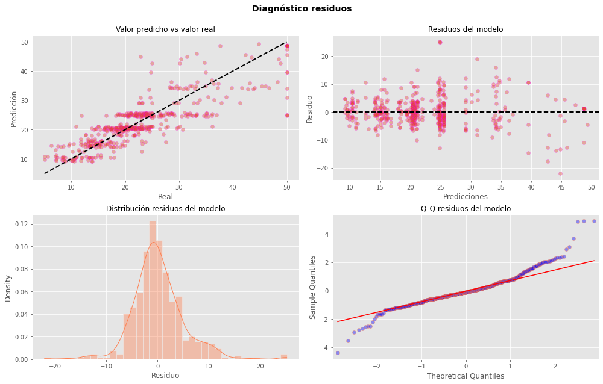

```python
# Gráficos:Diagnóstico errores (residuos) de las predicciones de validación cruzada
# ==============================================================================
cv_predicciones = cross_val_predict(estimator = modelo4_sinRM, X = X_todos, y = y_todos, cv = cv)

fig, axes = plt.subplots(nrows=2, ncols=2, figsize=(14, 9))

axes[0, 0].scatter(y_todos, cv_predicciones, edgecolors=(1, 0, 1), alpha = 0.4)
axes[0, 0].plot([y_todos.min(), y_todos.max()], [y_todos.min(), y_todos.max()],'k--', color = 'black', lw=2)
axes[0, 0].set_title('Valor predicho vs valor real', fontsize = 12, fontweight = "normal")
axes[0, 0].set_xlabel('Real')
axes[0, 0].set_ylabel('Predicción')
axes[0, 0].tick_params(labelsize = 10)

#axes[0, 1].scatter(list(range(len(y_train))), y_train - cv_prediccones, edgecolors=(1, 0, 1), alpha = 0.4)
axes[0, 1].scatter(cv_predicciones, y_todos - cv_predicciones, edgecolors=(1, 0, 1), alpha = 0.4)

axes[0, 1].axhline(y = 0, linestyle = '--', color = 'black', lw=2)
axes[0, 1].set_title('Residuos del modelo', fontsize = 12, fontweight = "normal")
axes[0, 1].set_xlabel('Predicciones')
axes[0, 1].set_ylabel('Residuo')
axes[0, 1].tick_params(labelsize = 10)

sns.histplot(data = y_todos - cv_predicciones,stat = "density",kde  = True,line_kws= {'linewidth': 1},color = "coral",alpha = 0.4, ax = axes[1, 0])

axes[1, 0].set_title('Distribución residuos del modelo', fontsize = 12,fontweight = "normal")
axes[1, 0].set_xlabel("Residuo")
axes[1, 0].tick_params(labelsize = 10)


sm.qqplot( y_todos - cv_predicciones, fit = True, line  = 'q', ax  = axes[1, 1], color = 'coral',alpha = 0.4, lw = 2)
axes[1, 1].set_title('Q-Q residuos del modelo', fontsize = 12, fontweight = "normal")
axes[1, 1].tick_params(labelsize = 10)

fig.tight_layout()
plt.subplots_adjust(top=0.9)
fig.suptitle('Diagnóstico residuos', fontsize = 14, fontweight = "bold");
```

- El análisis gráfico de los errores (residuos) de las precciones sobre la validación cruzada sin RM reflejan que la función de distribución se aproxima a la normal
- Sin embargo, el gráfico de residuos vs. predicciones se observa que los errores son más grades cuanto mayor el el valor de la predicción de la variable objetivo.
- Este mimo efecto se observa en la gráfica qqplot donde las colas de los valores inferiores y superiores se alejan de los valores teóricos.
- Como conclusión el modelo se ajusta bien en los valores centrales de la variable objetivo, pero pierde precisión en los valores más extremos, tienen problemas de dispersión irregular.
- En todos los casos la varianza de los residuos aumenta con los valores ajustados, esto indica que la variabilidad de los errores aumenta al aumentar su media como se esperaba al existir outliers de la variable objetivo MEDV.
- Para mejorar estos resultados se podría utilizar pruebas de igualdad de varianza (complementarias a los análisis gráficos), considera utilizar transformaciones de las variables o modelar la heterogeneidad encontrada con modelos generalizados (GLM) o modelos mixtos (MM).

##### 5.4.2) Modelo5 : Randon Forest Regressor

##### a) Métricas de la Validación Cruzada

```python
# Validación cruzada
# ==============================================================================
cv = KFold(n_splits=10, random_state=123, shuffle=True)

modelo5s_r2_scores = cross_val_score(modelo5_sinRM, X_todos, y_todos, cv = cv, scoring ="r2")
modelo5s_r2_mean = np.mean(modelo5s_r2_scores)
modelo5s_mse_scores = cross_val_score(modelo5_sinRM, X_todos, y_todos, cv = cv,scoring = "neg_mean_absolute_error")
modelo5s_mse_media= abs(np.mean(modelo5s_mse_scores))
modelo5s_rmse=np.sqrt(modelo5s_mse_media)

print("1. MSE de cada n-splits: ", modelo5s_mse_scores)
print("2. MSE media: ",modelo5s_mse_media)
print("3. RMSE: ",modelo5s_rmse)
print("4. R^2 de cada n_splits", modelo5s_r2_scores)
print("5. R^2 media :" ,modelo5s_r2_mean)
```

```
1. MSE de cada n-splits:  [-3.38705633 -2.58036788 -2.23656383 -2.50371142 -2.03511839 -2.13095483
 -2.87407618 -2.21666852 -3.11299667 -2.93838032]
2. MSE media:  2.601589436945506
3. RMSE:  1.6129443378323711
4. R^2 de cada n_splits [0.82504014 0.64685642 0.87442264 0.87239721 0.91457849 0.90636305
 0.82347976 0.80338433 0.76942102 0.76963735]
5. R^2 media : 0.8205580404705959
```

```python
model_rdos_cruzados= np.append(model_rdos_cruzados,[[modelo5s_mse_media,modelo5s_rmse, modelo5s_r2_mean]],axis=0)
```

##### b) Gráficos - Diagnóstico errores (residuos) de las predicciones de validación cruzada

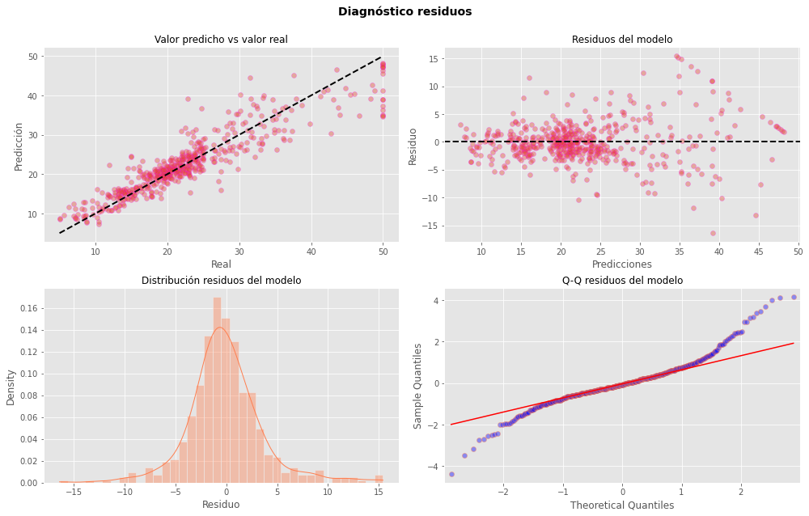

```python
# Gráficos: Diagnóstico errores (residuos) de las predicciones de validación cruzada
# ==================================================================================
cv_predicciones = cross_val_predict(estimator = modelo5_sinRM, X = X_todos, y = y_todos, cv = cv)

fig, axes = plt.subplots(nrows=2, ncols=2, figsize=(14, 9))

axes[0, 0].scatter(y_todos, cv_predicciones, edgecolors=(1, 0, 1), alpha = 0.4)
axes[0, 0].plot([y_todos.min(), y_todos.max()], [y_todos.min(), y_todos.max()],'k--', color = 'black', lw=2)
axes[0, 0].set_title('Valor predicho vs valor real', fontsize = 12, fontweight = "normal")
axes[0, 0].set_xlabel('Real')
axes[0, 0].set_ylabel('Predicción')
axes[0, 0].tick_params(labelsize = 10)

#axes[0, 1].scatter(list(range(len(y_train))), y_train - cv_prediccones, edgecolors=(1, 0, 1), alpha = 0.4)
axes[0, 1].scatter(cv_predicciones, y_todos - cv_predicciones, edgecolors=(1, 0, 1), alpha = 0.4)

axes[0, 1].axhline(y = 0, linestyle = '--', color = 'black', lw=2)
axes[0, 1].set_title('Residuos del modelo', fontsize = 12, fontweight = "normal")
axes[0, 1].set_xlabel('Predicciones')
axes[0, 1].set_ylabel('Residuo')
axes[0, 1].tick_params(labelsize = 10)

sns.histplot(data = y_todos - cv_predicciones,stat = "density",kde  = True,line_kws= {'linewidth': 1},color = "coral",alpha = 0.4, ax = axes[1, 0])

axes[1, 0].set_title('Distribución residuos del modelo', fontsize = 12,fontweight = "normal")
axes[1, 0].set_xlabel("Residuo")
axes[1, 0].tick_params(labelsize = 10)


sm.qqplot( y_todos - cv_predicciones, fit = True, line  = 'q', ax  = axes[1, 1], color = 'coral',alpha = 0.4, lw = 2)
axes[1, 1].set_title('Q-Q residuos del modelo', fontsize = 12, fontweight = "normal")
axes[1, 1].tick_params(labelsize = 10)

fig.tight_layout()
plt.subplots_adjust(top=0.9)
fig.suptitle('Diagnóstico residuos', fontsize = 14, fontweight = "bold");
```

- En el modelo 5_sinRM Randon Forest Regressor, el análisis gráfico de los errores (residuos) de las precciones sobre la validación cruzada reflejan que la función de distribución se aproxima a la normal y con mayor precisión que el modelo anterior, al concentrar los errores en una rango de [-10, a 10], mientras que en el Modelo 4 Decision Tree Regressor el rango es de [-15 a 15] aproximadamente.
- El gráfico de residuos vs. predicciones se observa que los errores son más grades cuanto mayor el el valor de la predicción de la variable objetivo.
- Este mismo efecto se observa en la gráfica qqplot donde las colas de los valores inferiores y superiores se alejan de los valores teóricos.
- Como conclusión el modelo se ajusta bien en los valores centrales de la variable objetivo, pero pierde precisión en los valores más extremos, tienen problemas de dispersión irregular. En todos los casos la varianza de los residuos aumenta con los valores ajustados, esto indica que la variabilidad de los errores aumenta al aumentar su media, como se preveía al darse outliers en la variable objetivo.
- Para mejorar estos resultados se podría utilizar pruebas de igualdad de varianza (complementarias a los análisis gráficos), considera utilizar transformaciones de las variables o modelar la heterogeneidad encontrada con modelos generalizados (GLM) o modelos mixtos (MM).

#### 4.3 Sumario de Métricas de Validación Cruzada

```python
row_indices = ["Modelo 4: Decision Tree Regressor", "Modelo 5: Random Forest Regressor","Modelo 4_sinRM : Decision Tree Regressor", "Modelo 5_sinRM: Random Forest Regressor"]
column_names = ["MSE","RMSE", "R^2"]
resultados2 = pd.DataFrame(model_rdos_cruzados, index=row_indices,columns=column_names)
resultados2.sort_values(by="MSE")
```

[output not shown]